# Bioanalyzer analysis of input samples

Marcelo Mora

6 de marzo de 2017

# Objective

The objective of this analysis is to analyze the bioanalyzer data in order to estimate the size distribution of the input DNA samples

# Strategy

The first step is to estimate the migration time of each size band in the bioanalyzer size standard ladder.

image:

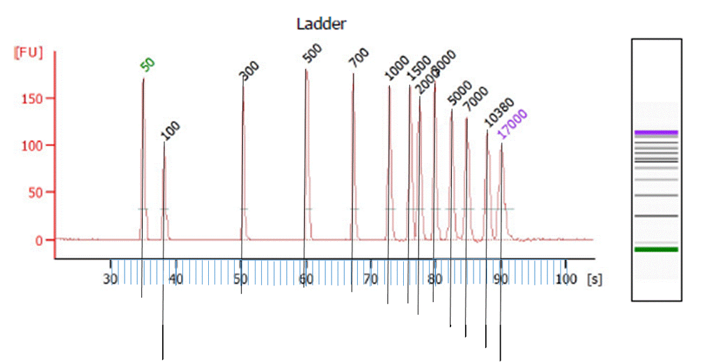

Once migration time of each ladder band has been estimated I will plot migration time over the base pairs (based on ladder band sizes)

```r
#load functions and libraries
source("C:/Users/marcelo/Dropbox/uptake/Everything_else/Bioanalyzer images/bio_functions.R")

#########load ladder band sizes and migration times##########
ladder_sizes<- c(50,100,300,500,700,1000,1500,2000,3000,5000,7000,10380,17000)

migration_time<- c(35,38,50,60,67,72.5,75.8,77.2,80,82.5,85,88,90)
#############################################################

#make a dataframe
cal_curve<- data.frame(ladder_sizes, migration_time)


cal_curve$log_time<- log(migration_time)

#check dataframe
str(cal_curve)
```

```
## 'data.frame':    13 obs. of  3 variables:
##  $ ladder_sizes  : num  50 100 300 500 700 1000 1500 2000 3000 5000 ...
##  $ migration_time: num  35 38 50 60 67 72.5 75.8 77.2 80 82.5 ...
##  $ log_time      : num  3.56 3.64 3.91 4.09 4.2 ...
```

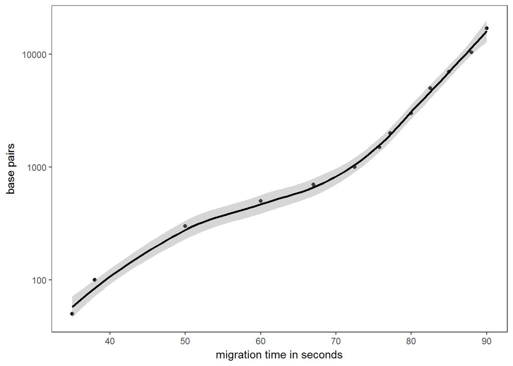

```r
p <- ggplot(aes(x =migration_time, y =ladder_sizes), data = cal_curve) +
  geom_point()+
  geom_smooth(method = "loess", colour = "black") +
  scale_y_log10()+
   labs(x = "migration time in seconds", y = "base pairs") +
  theme_bw() +
  theme(panel.grid.major = element_blank(),
        panel.grid.minor = element_blank(),
        plot.title = element_text(size = rel(1.2), face = "bold", vjust = 1.5))

ggsave("C:/Users/marcelo/Dropbox/uptake/Everything_else/Bioanalyzer images/curve.png", width = 50, height = 30, units = "cm")


p #load plot
```

Now that I now that the local polynomial regression fitting curve (loess) does a decent job fitting the points of the curve, I can apply this model to the data and then predict the base pair size for each input according to their migration times.

Now I will fit the loess model to the data and then test test if the predict function would help me estimate base pairs from migration times

```r
#making a loess model to my data so later I can predict the base pairs based on migration times using the loess model
model <- loess(ladder_sizes ~ migration_time, data = cal_curve)

#making fake migration time to test is the predicted function worked

fake_times<- c(50, 75, 78, 80, 60)

#predicting the base pairs for the fake migration times
predict(model, newdata = fake_times)
```

```
## [1]  252.0992 1265.6643 2214.8411 2999.4373  389.0699
```

## Sample names

I need to load the table with the samples names.

```r
#load table with samples names
periDNA<- read.table("C:/Users/marcelo/Dropbox/uptake/Everything_else/summary/periDNA.txt", header=TRUE, comment.char="")

datatable(periDNA, options = list(pageLength = 5))
```

|  | X.ID | recipient_strain | recipient_genotype | donor_DNA | donor_genotype | donor_size |
| --- | --- | --- | --- | --- | --- | --- |
| 1 | UP01 | RR3117 | rec2::spc | RR3133 | 86-028NPNalR | 6kb |
| 2 | UP02 | RR3125A | rec2del | RR3133 | 86-028NPNalR | 6kb |
| 3 | UP03 | RR3125B | rec2del | RR3133 | 86-028NPNalR | 6kb |
| 4 | UP04 | RR3117 | rec2::spc | RR1361 | PittGG | 6kb |
| 5 | UP05 | RR3125A | rec2del | RR1361 | PittGG | 6kb |
| 6 | UP06 | RR3125B | rec2del | RR1361 | PittGG | 6kb |
| 7 | UP07 | RR3117 | rec2::spc | RR3133 | 86-028NPNalR | 0.25kb |
| 8 | UP08 | RR3125A | rec2del | RR3133 | 86-028NPNalR | 0.25kb |
| 9 | UP09 | RR3125B | rec2del | RR3133 | 86-028NPNalR | 0.25kb |
| 10 | UP10 | RR3117 | rec2::spc | RR1361 | PittGG | 0.25kb |

[output cut: 6 more lines]

## NP long fragment bioanalyzer data

```r
#load NP 6kb input bioanalyzer data
UP13<- read.csv(file = "C:/Users/marcelo/Dropbox/uptake/Everything_else/Bioanalyzer images/input_excel/UP13.csv")
```

*NP long fragment data distribution size of sheared DNA*

Now to build the figure I will predict the base pairs of the input based on the each migration time using the fitted loess model on the ladder curve

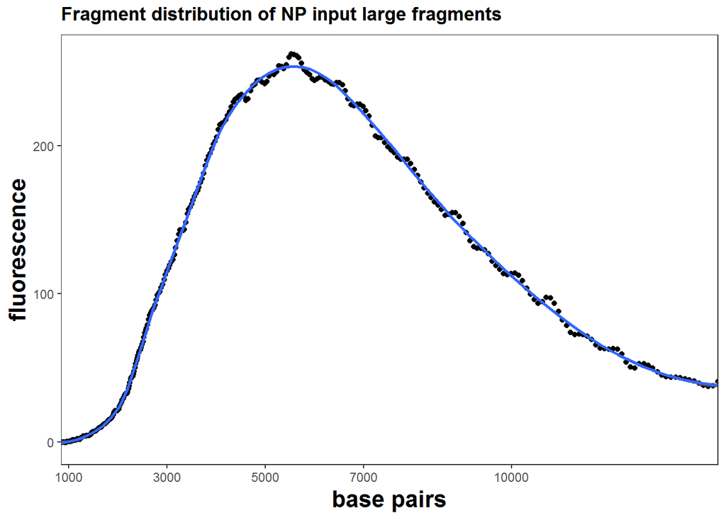

```r
#predicting the base pairs for the input migration times
UP13$bases<- predict(model, newdata = UP13$Time)

p <- ggplot(aes(x = bases, y = Value), data = UP13) +
  geom_point()+
  geom_smooth(method = "loess", span = 0.2)+ #span controls the amount of smoothing
  scale_x_continuous(breaks = c(1000,3000,5000,7000,10000,15000), expand = c(0, 0))+
  ggtitle("Fragment distribution of NP input large fragments") +
  labs(x = "base pairs", y = "fluorescence") +
  theme_bw() +
  theme(panel.grid.major = element_blank(),
        panel.grid.minor = element_blank(),
        plot.title = element_text(size = rel(1.2), face = "bold", vjust = 1.5),
        axis.title = element_text(face = "bold", size = 16, color = "black"))

ggsave("C:/Users/marcelo/Dropbox/uptake/Everything_else/Bioanalyzer images/UP13.png", width = 50, height = 30, units = "cm")

p
```

Now I need to repeat all the procedure for the rest of the input samples. Also I need to calculate the relative numbers of fragments. This will be done by dividing fluorecence over base pairs

To do this I will:

1. make a function in which I load all the input bioanalyzer data as a list
2. add the sample names to the input data list
3. predict the base pairs based on the migration times using the loess function model of the ladder data
4. calculate the relative number of molecules
5. plot all the input samples

```r
#  1. make a list of dataframes where each dataframe is an input sample
l.df<- setNames(lapply(ls(pattern="UP[0-9]+"), function(x) get(x)), ls(pattern="UP[0-9]+"))

l.df<- add.names(l.df)  #2. add sample name to each dataframe

l.df<- add.bases(l.df) #3. predicting the base pairs for the input migration times

l.df<- add.rel_molecules(l.df) # 4.calculate the relative number of molecules by dividing fluorecence by base pairs
```

Now I have a list with all input data, but ggplot won’t accept list objects so I will transform the list into a lond dataframe

```r
d.df<- ldply(l.df, rbind) #bind all dataframes of a list into one big dataframe with all samples
```

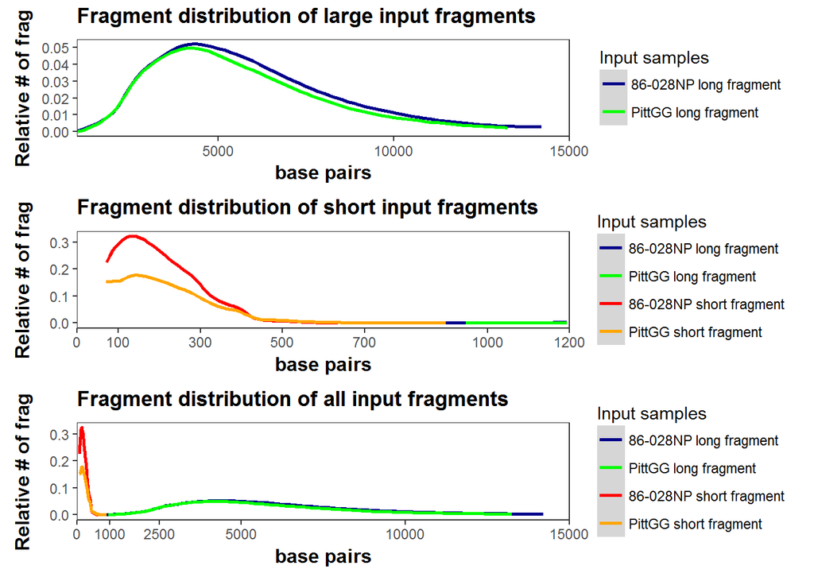

```r
# 5. Plot all input data.
p0 <- ggplot(aes(x = bases, y =rel_mol, color = sample), data = d.df) +
  geom_smooth(method = "loess", span = 0.2) + #span controls the amount of smoothing
  scale_x_continuous(limits = c(1000,15000), expand = c(0, 0))+
  scale_color_manual(values = c("UP13" = "dark blue", "UP14" = "green", "UP15" = "red", "UP16" = "orange" ), name = "Input samples",labels = c("UP13" = "86-028NP long fragment", "UP14" = "PittGG long fragment", "UP15" = "86-028NP short fragment", "UP16" = "PittGG short fragment" )) +
    ggtitle("Fragment distribution of large input fragments") +
  labs(x = "base pairs", y = "Relative # of frag") +
  theme_bw() +
  theme(panel.grid.major = element_blank(),
        panel.grid.minor = element_blank(),
        plot.title = element_text(size = rel(1.2), face = "bold", vjust = 1.5),
        axis.title = element_text(face = "bold", size = 12, color = "black"))

ggsave("C:/Users/marcelo/Dropbox/uptake/Everything_else/Bioanalyzer images/large.png", width = 50, height = 30, units = "cm")

p1 <- ggplot(aes(x = bases, y =rel_mol, color = sample), data = d.df) +
  geom_smooth(method = "loess", span = 0.2) + #span controls the amount of smoothing
  scale_x_continuous(limits = c(0,1200), breaks = c(0,100,300,500,700,1000,1200), expand = c(0, 0))+
    scale_color_manual(values = c("UP13" = "dark blue", "UP14" = "green", "UP15" = "red", "UP16" = "orange" ), name = "Input samples",labels = c("UP13" = "86-028NP long fragment", "UP14" = "PittGG long fragment", "UP15" = "86-028NP short fragment", "UP16" = "PittGG short fragment" )) +
    ggtitle("Fragment distribution of short input fragments") +
  labs(x = "base pairs", y = "Relative # of frag") +
  theme_bw() +
  theme(panel.grid.major = element_blank(),
        panel.grid.minor = element_blank(),
        plot.title = element_text(size = rel(1.2), face = "bold", vjust = 1.5),
        axis.title = element_text(face = "bold", size = 12, color = "black"))

ggsave("C:/Users/marcelo/Dropbox/uptake/Everything_else/Bioanalyzer images/small.png", width = 50, height = 30, units = "cm")

p2 <- ggplot(aes(x = bases, y =rel_mol, color = sample), data = d.df) +
  geom_smooth(method = "loess", span = 0.2) + #span controls the amount of smoothing
  scale_x_continuous(limits = c(0,15000), breaks = c(0,1000,2500,5000,10000,15000), expand = c(0, 0))+
    scale_color_manual(values = c("UP13" = "dark blue", "UP14" = "green", "UP15" = "red", "UP16" = "orange" ), name = "Input samples",labels = c("UP13" = "86-028NP long fragment", "UP14" = "PittGG long fragment", "UP15" = "86-028NP short fragment", "UP16" = "PittGG short fragment" )) +
    ggtitle("Fragment distribution of all input fragments") +
  labs(x = "base pairs", y = "Relative # of frag") +
  theme_bw() +
  theme(panel.grid.major = element_blank(),
        panel.grid.minor = element_blank(),
        plot.title = element_text(size = rel(1.2), face = "bold", vjust = 1.5),
        axis.title = element_text(face = "bold", size = 12, color = "black"))

ggsave("C:/Users/marcelo/Dropbox/uptake/Everything_else/Bioanalyzer images/input_all.png", width = 50, height = 30, units = "cm")

plot_grid(p0,p1,p2, ncol = 1, align = 'v')
```

Now I will plot the same picture but including the fluorescence instead of the relative number of fragments

[figure not shown]

```r
p <- ggplot(aes(x = bases, y = Value), data = UP13) +
  geom_point()+
  geom_smooth(method = "loess", span = 0.2)+ #span controls the amount of smoothing
  scale_x_continuous(breaks = c(1000,3000,5000,7000,10000,15000), expand = c(0, 0))+
  ggtitle("Fragment distribution of NP input large fragments") +
  labs(x = "base pairs", y = "fluorescence") +
  theme_bw() +
  theme(panel.grid.major = element_blank(),
        panel.grid.minor = element_blank(),
        plot.title = element_text(size = rel(1.2), face = "bold", vjust = 1.5),
        axis.title = element_text(face = "bold", size = 16, color = "black"))


# 5. Plot all input data.
p0 <- ggplot(aes(x = bases, y =Value, color = sample), data = d.df) +
  geom_smooth(method = "loess", span = 0.2) + #span controls the amount of smoothing
   scale_x_continuous(limits = c(0,15000), breaks = c(0,1000,3000,5000,7000,10000,15000), expand = c(0, 0))+
  scale_y_continuous(limits = c(0,300))+
  scale_color_manual(values = c("UP13" = "dark blue", "UP14" = "green", "UP15" = "red", "UP16" = "orange" ), name = "Input samples",labels = c("UP13" = "86-028NP long fragment", "UP14" = "PittGG long fragment", "UP15" = "86-028NP short fragment", "UP16" = "PittGG short fragment" )) +
    ggtitle("Fragment distribution of large input fragments") +
  labs(x = "base pairs", y = "fluorescence") +
  theme_bw() +
  theme(panel.grid.major = element_blank(),
        panel.grid.minor = element_blank(),
        plot.title = element_text(size = rel(1.2), face = "bold", vjust = 1.5),
        axis.title = element_text(face = "bold", size = 12, color = "black"))


p1 <- ggplot(aes(x = bases, y =Value, color = sample), data = d.df) +
  geom_smooth(method = "loess", span = 0.2) + #span controls the amount of smoothing
  scale_x_continuous(limits = c(1000,15000), breaks = c(1000,3000,5000,7000,10000,15000), expand = c(0, 0))+
  scale_y_continuous(limits = c(0,300))+
    scale_color_manual(values = c("UP13" = "dark blue", "UP14" = "green", "UP15" = "red", "UP16" = "orange" ), name = "Input samples",labels = c("UP13" = "86-028NP long fragment", "UP14" = "PittGG long fragment", "UP15" = "86-028NP short fragment", "UP16" = "PittGG short fragment" )) +
    ggtitle("Fragment distribution of short input fragments") +
  labs(x = "base pairs", y = "fluorescence") +
  theme_bw() +
  theme(panel.grid.major = element_blank(),
        panel.grid.minor = element_blank(),
        plot.title = element_text(size = rel(1.2), face = "bold", vjust = 1.5),
        axis.title = element_text(face = "bold", size = 12, color = "black"))


p2 <- ggplot(aes(x = bases, y =Value, color = sample), data = d.df) +
  geom_smooth(method = "loess", span = 0.2) + #span controls the amount of smoothing
  scale_x_continuous(limits = c(0,1200), breaks = c(0,250,500,700,1000,1200), expand = c(0, 0))+
  scale_y_continuous(limits = c(0,100))+
    scale_color_manual(values = c("UP13" = "dark blue", "UP14" = "green", "UP15" = "red", "UP16" = "orange" ), name = "Input samples",labels = c("UP13" = "86-028NP long fragment", "UP14" = "PittGG long fragment", "UP15" = "86-028NP short fragment", "UP16" = "PittGG short fragment" )) +
    ggtitle("Fragment distribution of all input fragments") +
  labs(x = "base pairs", y = "fluorescence") +
  theme_bw() +
  theme(panel.grid.major = element_blank(),
        panel.grid.minor = element_blank(),
        plot.title = element_text(size = rel(1.2), face = "bold", vjust = 1.5),
        axis.title = element_text(face = "bold", size = 12, color = "black"))


plot_grid(p0,p1,p2, ncol = 1, align = 'v')
```